# Estimering av sosial tillit

For studenter

Author

Derek J. Clark

Published

February 5, 2024

## Innledning

Dette dokumentet går gjennom en enkel estimering av en lineær regresjon for sosial tillit, delvis basert på Saltkjel and Malmberg-Heimonen (2014), med data fra [Norsk medborgerpanel runde 26, 2023](https://surveybanken.sikt.no/no/study/547be65b-fb02-480a-9192-6781233cdd17/undefined?type=studyMetadata&datafile=5343ae2b-5f89-42d2-83c0-ec1bf7a97651/9&elements=%5B%5D). Vi laster inn pakker og datafila.

```r
rm(list=ls())

suppressPackageStartupMessages({
  library(tidyverse)
  library(car)
})

# pakken "car" brukes til å utføre en kollineæritetstest

data <- read.csv("MP_runde26_2023.csv")
```

## Variabler

Datasettet inneholder 12021 observasjoner av 440 variabler i utgangspunktet. For å forklare sosial tillit bruker Saltkjel and Malmberg-Heimonen (2014) bakgrunnsvariabler (kjønn, aldersgruppe, gift/samboer, og innvandrerstatus), og sosioøkonomiske variabler (utdanning, problemer i oppvekst, helsestatus, sysselsetting, opplevd fattigdom, og inntekt). “Problemer i oppvekst” finnes ikke i dette datasettet så vidt jeg vet, og det nærmeste vi kommer “sysselsetting” i vårt datasett er r26_bgday som spør om hva intervjuobjektet har gjort de siste 7 dagene. Her er det tre kategorier for sysselsetting (heltid, deltid over 30 timer i arbeid, deltid under 30 timer). Ettersom vi her gjennomfører et eksempel på hvordan vi estimerer en ligning for sosial tillit - uten nærmere spesifisert problemstilling - utelater jeg denne variabelen.

Jeg estimerer to versjoner av tillitsligningen (som tilsvarer versjoner av Model 1 og Model 2, tabell 3 i Saltkjel and Malmberg-Heimonen (2014)):

$$tillit = \alpha_0 + \alpha_1\:kjønn +\alpha_2\:alder +\alpha_3\:sivilstatus +\alpha_4\:innvandrerstatus+ error \hspace{2cm}M1$$
$$tillit = M1 + \alpha_5\:utdanning+\alpha_6\: inntekt + error \hspace{2cm}M2$$

Her er “tillit” vår avhengige variabel, og denne er numerisk og tar diskrete heltallverdier 0-10. “Kjønn” er en dummyvariabel som tar verdi 0 for kvinne og 1 for mann. I min modell er også “sivil-” og “innvandrerstatus” dummyvariabler (selv om disse består av flere kategorier i datasettet). “Alder”, “utdanning” og “inntekt” er kategoriske variabler som består av minst 3 kategorier/nivå. For mer om hvordan man kan bruke tidyverse for å behandle kategoriske variabler i R, se McNamara and Horton (2018).

### Sosial tillit

I datasettet er sosial tillit spurt om i r26_pccoo. Dette omtales i en del litteratur som horisontal eller mellommenneskelig tillit. Svarene er heltall fra 0 (kan ikke være forsiktig nok) til 10 (folk flest er til å stole på), samt 97 (ikke svart) og 98 (ikke spurt).

De som ikke svarer eller blir spurt om tillit må vi fjerne fra datasettet. Samtidig endrer vi variabelnavn til `tillit`

```r
# tillit uten de som ikke svarer eller blir spurt

data$tillit <- data$r26_pccoo

data1 <- subset(data, tillit != 97 & tillit != 98)
```

Nå har vi 7793 observasjoner i datasettet som heter `data1`.

### Kjønn

Nå kan vi lage en dummy variabel som tar verdi 1 for “mann” og 0 for “kvinne”. Dette er spurt om i spørsmål r26P1 (svaralternativ er 1 for Mann og 2 for Kvinne). Ved å se i [kodeboka](https://www.nsd.no/data/individ/publikasjoner/NSD3127/Kodebok%20-%20NMP%20runde%2026%20-%20v-104%20-%20no.html) finner vi at svaralternativ 1 og 2 er eneste muligheter. Her lager vi en dummyvariabel med base R, i en ny kolonne som heter “mann”.

```r
# Kjønnsdummy (1 for mann, 0 for kvinne)
data1$mann <- ifelse(data1$r26P1 == 1, 1, 0)
```

### Aldersgruppe

Spørsmål r26P5_2 spør om intervall for fødselsår med følgende svaralternativ: 1: 1959 eller tidligere, 2: 1960-1989, 3: 1990 eller senere. Verdiene 1, 2, 3 angir kategori, og gjøres om til en faktor med tre nivåer:

```r
# Aldersgruppe


data1 <- data1 %>%
  mutate(født = case_when(
    r26P5_2 == 1 ~ '1959_og_før',
    r26P5_2 == 2 ~ '1960_1989',
    TRUE ~ '1990_og_etter'
  )) %>%
  mutate(født = factor(født, levels = c('1959_og_før', '1960_1989', '1990_og_etter')))
```

Hadley Wickham har et kapittel om faktorer i sin bok [her](https://r4ds.hadley.nz/factors.html).

### Sivilstatus

Saltkjel and Malmberg-Heimonen (2014) bruker en dummyvariabel som viser om en person er gift/samboer eller ikke. Spørsmål r26_bgciv gir oss data på dette. Kategori 3 angir samboer og 4 angir gift. Det er totalt 7 kategorier, hvorav 3 og 4 er samboer/gift, og “ikke svart” (97), samt “ikke spurt” (98). Vi kan sette de siste verdiene til NA.

```r
# gift eller samboer

data1 <- data1 %>%
  mutate(gift_samboer = case_when(
    r26_bgciv %in% c(97, 98) ~ NA_real_,
    r26_bgciv %in% c(1, 2, 5, 6, 7) ~ 0,
    TRUE ~ 1
  ))
```

### Innvandrerstatus

Her må vi koble sammen spørsmål fra flere runder for å sikre oss så mange observasjoner som mulig. Innvandrerstatus er noe som ikke varierer over tid, slik at intervjuobjekter som ikke er spurt om dette i runde 26 kan ha svart på dette tidligere. Da kan vi koble sammen svar til dette spørsmålet fra flere runder. Vi må sjekke at vi kun har ett svar pr. observasjon.

I følgende kode lages et nytt datasett med svar fra alle relevante spørsmål. Dette kan du bruke dersom innvandringsbakgrunn er viktig for din problemstilling

```r
# innvandring

# lag datasett med de relevante variablene

innvandring_data <- data1 %>%
  dplyr::select(w01_k29, w03_r3k29, r4k29, r5k29, r11bk29,
                r14bk29, r16bk29, r18bk29, r22bk29, r25_bgimm)
```

Av totalt 7793 observasjoner har jeg klart å finne svar til innvandrerbakgrunn for 7563. Resten er ikke spurt. Totalt har 424 observasjoner har innvandret til Norge selv (første-generasjonsinnvandring). Jeg har laget en dummyvariabel for førstegenerasjonsinnvandrere: denne heter “dummy_innvandrer” og tar verdi 1 dersom en person har innvandret selv, og 0 ellers.

### Utdanning

Vi bruker her spørsmål r26P4_1 med tre nivåer. Her bruker vi “høyere utdanning” som sammenligningsnivå som i Saltkjel and Malmberg-Heimonen (2014).

```r
# education r26P4_1


data1 <- data1 %>%
  mutate(utdanning = factor(r26P4_1,
                            levels = c(1, 2, 3),
                            labels = c("grunnskole", "videregående", "høyere"),
                            exclude = 97)) %>%
  mutate(utdanning = fct_relevel(utdanning, "høyere"))

# siste linje sikrer at 'høyere' er referansenivå
# fct_relevel kommer fra pakke forcats (en del av tidyverse)
```

### Inntekt

Spørsmål r26k2_bginc gir informasjon om inntektskategori. Her er det 8 mulige kategorier, og jeg har gjort disse om til en faktor med 8 nivå i en kolonne som heter “inntekt” (med “under 150” som referansekategori).

## Deskriptiv statistikk

Nå har vi 7 variabler som kan settes sammen som et eget datasett. Jeg har kommentert ut dette ettersom ikke alle variabler er definert i koden ovenfor.

```r
#reduced_data <- data1 %>%
#  dplyr::select(tillit, mann, født, gift_samboer, dummy_innvandrer, utdanning, inntekt)

# saveRDS(reduced_data, "reduced_data.rds")
```

Det er dette datasettet som jeg vil bruke for å estimere regresjonsmodellen. Jeg laster datasettet inn ettersom vi ikke har tatt alle steg for å lage det tidligere:

```r
reduced_data <- readRDS("reduced_data.rds")
```

Nå må dere beskrive datasettet. Det kan være lurt å finne den prosentvise fordelingen av dine variabler (se Tabell 1 i Saltkjel and Malmberg-Heimonen (2014)). Dette er ikke nødvendigvis det samme som i kodeboka ettersom jeg har utelukket alle observasjoner som ikke svarer på tillit. Vi kan finne både fordelingen av svar og hvor stor andel av NA vi har for hver variabel. For eksempel er ca. 5.4% av våre observasjoner førstegenerasjonsinnvandrere, ca. 91.6% er ikke, og vi mangler data på ca. 3%. Det er greit å vær obs på følgende: når du estimerer en lineær regresjon i R utelates i utgangspunktet observasjoner som ikke er fullstendig (hvor det er en NA i minst én kolonne).

Vi kan beregne gjennomsnitt og standard avvik til `tillit` .

```r
tillit_gj <- mean(reduced_data$tillit, na.rm = TRUE)
tillit_sd <- sd(reduced_data$tillit, na.rm = TRUE)


cat("tillit - gjennomsnitt:", tillit_gj, "\n")
```

```
tillit - gjennomsnitt: 7.06262
```

```r
cat("tillit standard avvik:", tillit_sd, "\n")
```

```
tillit standard avvik: 1.792189
```

## Regresjonsanalyse

Her estimeres vår versjon av Modell 1 og 2 i tabell 3 av Saltkjel and Malmberg-Heimonen (2014). Vi bruker lineær regresjon, først med bakgrunnsvariablene (kjønn, alder, sivilstatus og innvandrerstatus).

```r
# modell 1 med bakgrunnsvariabler
model_1 <- lm(tillit ~ mann + født + gift_samboer + dummy_innvandrer , data = reduced_data)


summary(model_1)
```

```
Call:
lm(formula = tillit ~ mann + født + gift_samboer + dummy_innvandrer,
    data = reduced_data)

Residuals:
    Min      1Q  Median      3Q     Max
-7.1769 -0.6858  0.5730  0.9813  3.7411

Coefficients:
                  Estimate Std. Error t value Pr(>|t|)
(Intercept)        7.09415    0.05592 126.852  < 2e-16 ***
mann              -0.25010    0.04567  -5.477 4.51e-08 ***
født1960_1989     -0.15824    0.04722  -3.351 0.000809 ***
født1990_og_etter -0.46102    0.09413  -4.897 9.96e-07 ***
gift_samboer       0.33283    0.05161   6.450 1.21e-10 ***
dummy_innvandrer  -0.12414    0.10137  -1.225 0.220763
---
Signif. codes:  0 '***' 0.001 '**' 0.01 '*' 0.05 '.' 0.1 ' ' 1

Residual standard error: 1.751 on 5974 degrees of freedom
  (1813 observations deleted due to missingness)
Multiple R-squared:  0.01654,   Adjusted R-squared:  0.01571
F-statistic: 20.09 on 5 and 5974 DF,  p-value: < 2.2e-16
```

Før vi tolker våre resultater bør vi se om de grunnleggende forutsetningene bak estimeringen er oppfylt. `plot()` kommandoen i base R hjelper oss litt på vei. Vi kan plotte residualene mot predikert verdi for å se om det er noe mønster (det bør det ikke være!). Hjelp til tolkning av disse figurene kan dere få [her](https://library.virginia.edu/data/articles/diagnostic-plots).

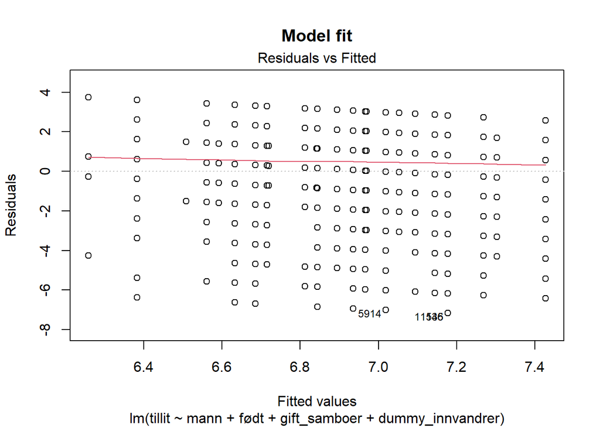

```r
plot(model_1, which = 1, main = "Model fit")
```

Her sjekkes om residualene er normalfordelt (som vi ønsker!):

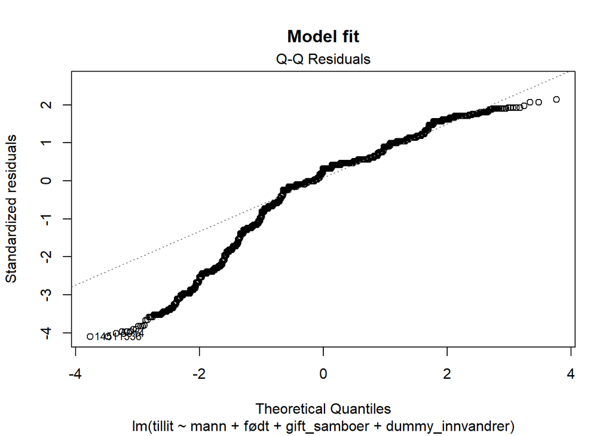

```r
plot(model_1, which = 2, main = "Model fit")
```

Mer om [QQ plott](https://library.virginia.edu/data/articles/understanding-q-q-plots).

Følgende figur sjekker om variansen til residualene er konstant (som vi ønsker!).

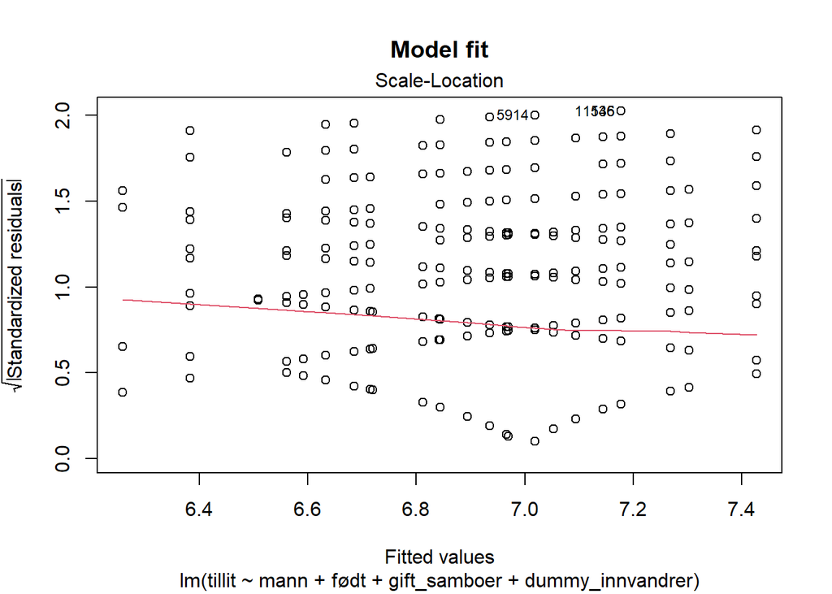

```r
plot(model_1, which = 3, main = "Model fit")
```

Til slutt en figur som viser om noen av observasjonene har mye effekt på vår regresjonsligning.

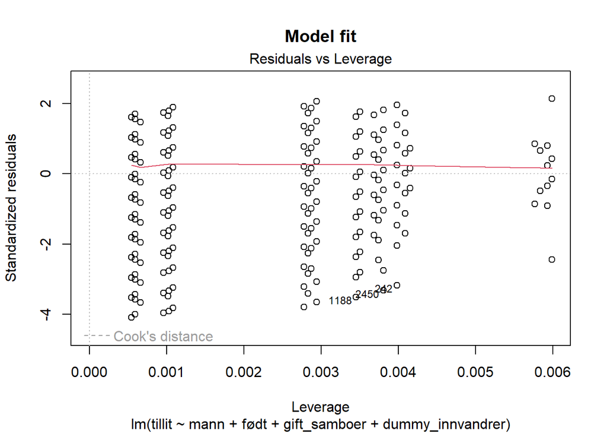

```r
plot(model_1, which = 5, main = "Model fit")
```

Man kan også sjekke om det er et lineært forhold mellom våre forklaringsvariabler ved å kjøre en [Variance Inflation Factor (VIF) test](https://no.wikipedia.org/wiki/Variansinflasjonsfaktor). Høye verdier av VIF (over 5) indikerer at to variabler har et lineært forhold.

```r
# VIF test for multicollineæritet
# vif() er en del av car pakken

vif(model_1)
```

```
                     GVIF Df GVIF^(1/(2*Df))
mann             1.016122  1        1.008029
født             1.033410  2        1.008250
gift_samboer     1.026787  1        1.013305
dummy_innvandrer 1.005705  1        1.002849
```

VIF verdier rundt 1 indikerer at det ikke er lineær korrelasjon mellom våre forklaringsvariabler. Legg dog merke til at modellen forklarer lite av variansen i `tillit`, og at vi har mistet ganske mange observasjoner. `Reduced_data` består av 7793 observasjoner, og 1813 av disse er utelatt fordi de mangler verdi. Fra vår deskriptiv statistikk kan vi se at ca 20% av observasjonene for `sivil_status` mangler.

Det finnes pakker som gir en mer oversiktlig utskrift av regresjonsresultatene, som for eksempel [jtools](https://cran.r-project.org/web/packages/jtools/vignettes/summ.html). Med denne pakken kan du også få resultatene fra en VIF test som en del av utskriften.

La oss se på og tolke våre regresjonskoeffisienter. Vår referansegruppe består av kvinner født 1959 og før, ugift og ikke førstegenerasjonsinnvandrer. Du ser hva som er referansegruppa ved å kombinere dummyvariablene som vi har spesifisert som 0, samt referansekategorien hvor det er flere enn to. For å måle kjønn satte vi inn verdi 0 for kvinne og 1 for mann, de som er gift/samboer fikk verdi 1, ugifte/ikke-samboer fikk verdi 0. En observasjon som ikke er innvandrer får verdi 0, innvandrer får 1. Alder har tre kategorier, og vi spesifiserte “født 1959 og før” som referanse.

Da viser “Intercept” gjennomsnittsverdien for tillit for referansegruppa som 7.09, og dette statistisk signifikant, dvs. statistisk sett er den ikke null (p<0.001). Koeffisienten på “mann” er -0.25. Dette viser at en mann har 0.25 poeng lavere tillit en en kvinne i gjennomsnitt dersom man holder de andre faktorene konstante (dvs ingen andre referanseverdier endres). Denne koeffisienten er også statistisk forskjellig fra null. De som er født mellom 1960-1989 har en redusert tillitsnivå på 0.16 sammenliknet med de som er født før 1959, og gruppa født etter 1990 har 0.46 lavere tillitsnivå enn referansegruppa. Begge koeffisientene er statistisk signifikante. Å være gift/ samboer øker tillitsnivå med 0.33 sammenliknet med ugift, og også denne koeffisient er forskjellig fra null statistisk sett. Koeffisienten på vår variabel på innvandrerstatus er ikke statistisk forskjellig fra 0, og dermed avdekker vi ingen effekt på tillit av å være førstegenerasjonsinnvandrer.

Legg merke til at vi sammenligner med en referansekategori her. Vi har de født i 1959 og før som referanse når vi ser på de andre to alderskategorier. Hva om vi ville sammenligne de som er født 1960-1989 med de født fra 1990? Da kan man bruke pakken [marginal effects](https://marginaleffects.com/vignettes/comparisons.html). Se spesielt på avsnittet om *Predictor types - logical and factor predictors*.

Som i Saltkjel and Malmberg-Heimonen (2014) kan vi utvide vår regresjonsmodell med flere sosio-økonomiske variabler. Her er referansegruppa kvinner født 1959 og før, ugift, ikke førstegenerasjonsinnvandrer, med høyere utdanning, og i inntektskategori “under 150 000kr”. (Tolk resultatene selv!).

```r
# modell 2 med alle variabler
model_2 <- lm(tillit ~ mann + født + gift_samboer + dummy_innvandrer+ utdanning + inntekt, data = reduced_data)


summary(model_2)
```

```
Call:
lm(formula = tillit ~ mann + født + gift_samboer + dummy_innvandrer +
    utdanning + inntekt, data = reduced_data)

Residuals:
    Min      1Q  Median      3Q     Max
-7.2936 -0.6631  0.3534  1.1109  4.0739

Coefficients:
                      Estimate Std. Error t value Pr(>|t|)
(Intercept)            7.51353    0.15643  48.032  < 2e-16 ***
mann                  -0.30994    0.04770  -6.497 8.86e-11 ***
født1960_1989         -0.34252    0.05165  -6.631 3.62e-11 ***
født1990_og_etter     -0.50806    0.09773  -5.199 2.07e-07 ***
gift_samboer           0.24106    0.05139   4.691 2.78e-06 ***
dummy_innvandrer      -0.18283    0.10060  -1.817  0.06921 .
utdanninggrunnskole   -0.74879    0.11135  -6.725 1.93e-11 ***
utdanningvideregående -0.51773    0.05264  -9.835  < 2e-16 ***
inntekt150-300        -0.41727    0.15995  -2.609  0.00911 **
inntekt300-400        -0.18831    0.15666  -1.202  0.22941
inntekt400-500        -0.10795    0.15697  -0.688  0.49164
inntekt500-600        -0.02642    0.15691  -0.168  0.86629
inntekt600-700         0.05295    0.15709   0.337  0.73605
inntekt700-1m          0.24372    0.15729   1.549  0.12133
inntekt1m+             0.19144    0.16775   1.141  0.25381
---
Signif. codes:  0 '***' 0.001 '**' 0.01 '*' 0.05 '.' 0.1 ' ' 1

Residual standard error: 1.712 on 5847 degrees of freedom
  (1931 observations deleted due to missingness)
Multiple R-squared:  0.05842,   Adjusted R-squared:  0.05617
F-statistic: 25.91 on 14 and 5847 DF,  p-value: < 2.2e-16
```

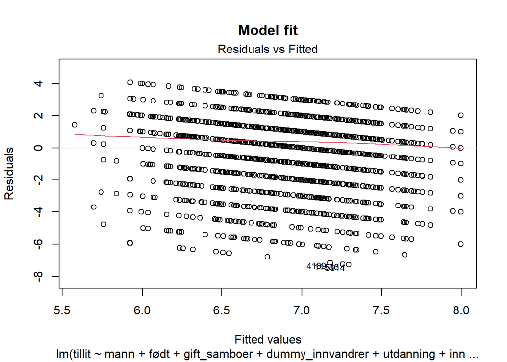

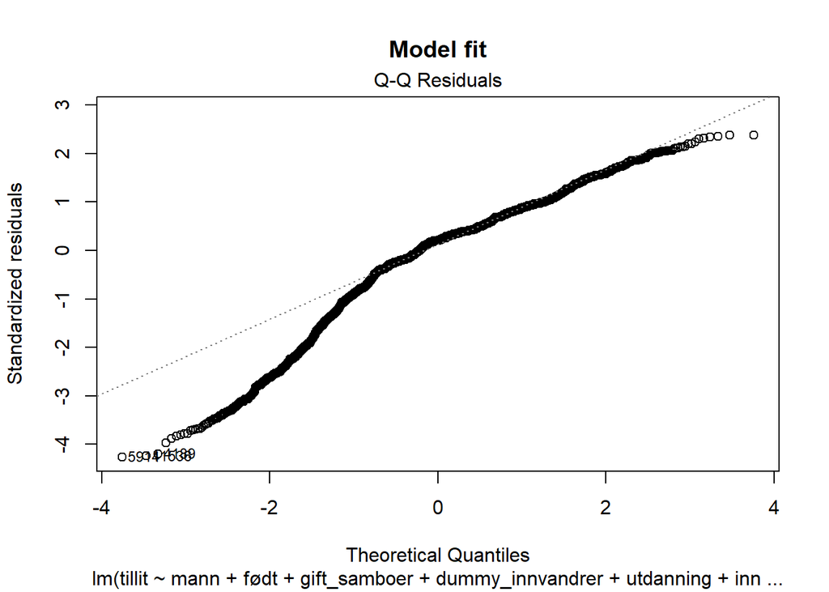

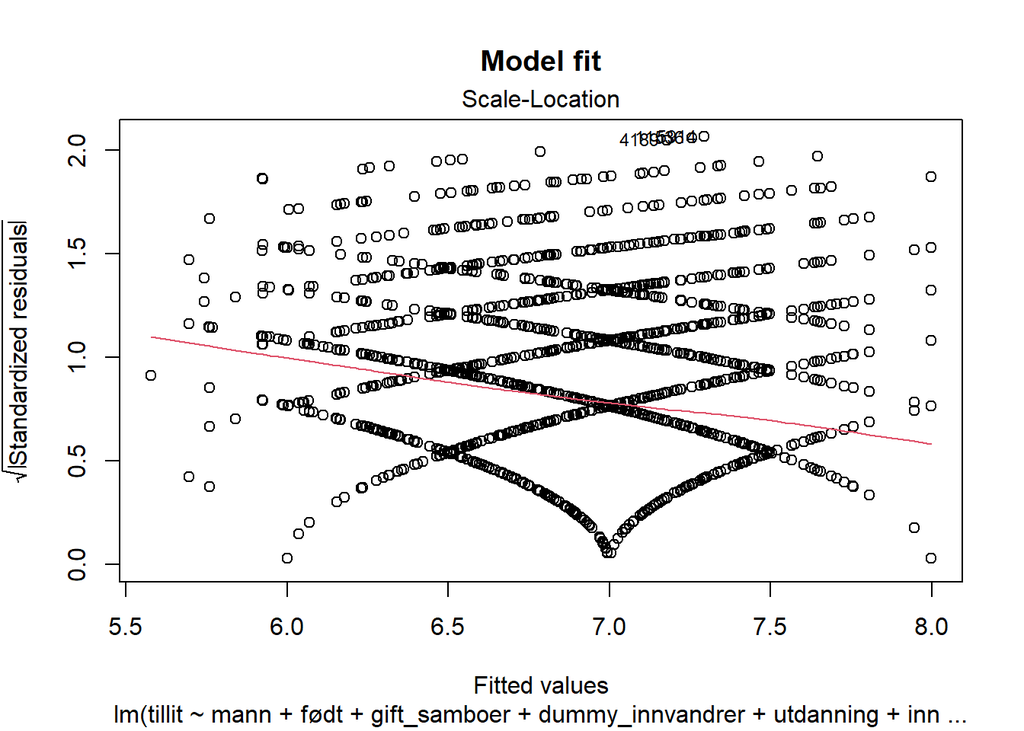

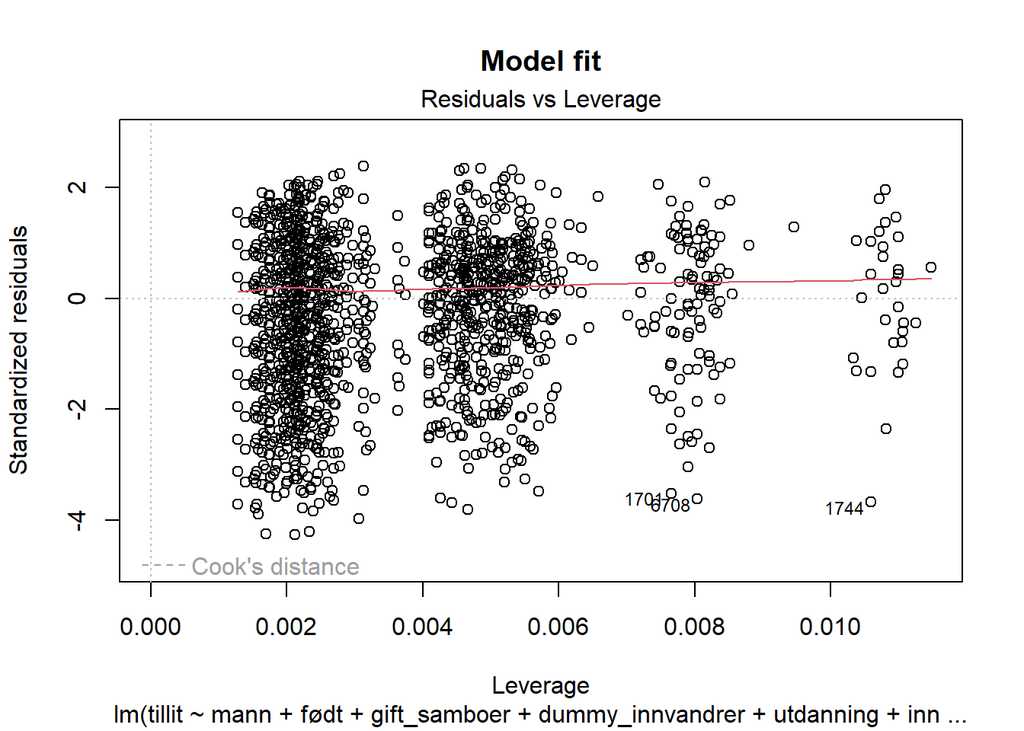

```r
plot(model_2, main = "Model fit")
```

```r
# VIF test for multicollineæritet

vif_model_2 <- vif(model_2)

print(vif_model_2)
```

```
                     GVIF Df GVIF^(1/(2*Df))
mann             1.137142  1        1.066368
født             1.386880  2        1.085200
gift_samboer     1.043279  1        1.021410
dummy_innvandrer 1.016972  1        1.008450
utdanning        1.195442  2        1.045640
inntekt          1.682624  7        1.037868
```

## Regresjon med standardiserte (beta) koeffisienter

I tabell 3 i Saltkjel and Malmberg-Heimonen (2014) er to typer koeffisient rapportert. Den første er tolket ovenfor, og viser den gjennomsnittlige endringen i tillit for en økning med én enhet i den uavhengige variabelen (eller en endring i kategori i forhold til referansen). Dette er avhengig av hvordan enhetene er målt, *og innebærer at man ikke kan uttale seg om den relative størrelsen på effektene som er identifisert i regresjonsanalysen*. Den andre koeffisienten i tabell 3 i Saltkjel and Malmberg-Heimonen (2014) er i parentes, og merket med Beta. Disse koeffisientene er standardisert, og kan i prinsipp sammenliknes. For å gjøre en slik analyse regnes alle variabler om slik at de måles i standardavvik fra gjennomsnittet. Tolkningen av en koeffisient i en slik analyse blir da hvor mange standard avvik tillit endrer seg når en forklaringsvariabel endrer seg med ett standard avvik. I en modell med kun kategoriske forklaringsvariabler må man spørre seg om dette er en meningsfull tilnærming! (Prøv for eksempel å tolke de standardiserte koeffisientene som presenteres i tabell 3).

## Interaksjonseffekter

En problemstilling kan kreve at vi utforsker om det er interaksjon mellom noen variabler. I forelesningen gis et motiverende eksempel.

I vårt datasett kan vi for eksempel spørre om effekten som utdanningsnivå har på tillit er forskjellige for menn og kvinner. Dette kan vi tegne fra datasettet som vi har laget:

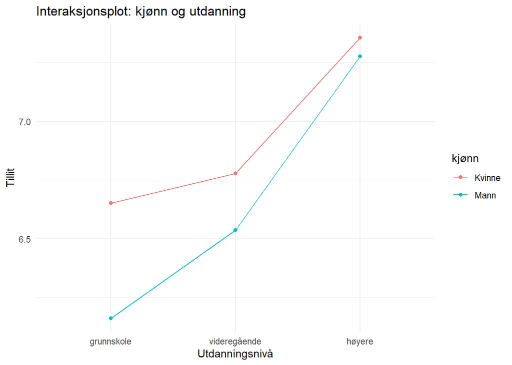

```r
# Lag variable for kjønn som label
reduced_data$kjønn <- ifelse(reduced_data$mann == 1, "Mann", "Kvinne")

# fjern NA
reduced_data_filtered <- reduced_data %>%
  filter(!is.na(utdanning))

# vi endrer rekkefølgen av faktornivå for at plottet skal se bra ut

reduced_data_filtered <- reduced_data_filtered %>%
  mutate(utdanning = fct_relevel(utdanning, "grunnskole", "videregående", "høyere"))

reduced_data_filtered %>%
  ggplot(aes(x = utdanning, y = tillit, group = kjønn, color = kjønn)) +
  geom_line(stat = "summary", fun = mean) +
  geom_point(stat = "summary", fun = mean) +
  labs(title = "Interaksjonsplot: kjønn og utdanning",
       x = "Utdanningsnivå",
       y = "Tillit") +
  theme_minimal()
```

Fra tegningen kan vi se at tillitsnivået til kvinner ligger over det til mannfolk i gjennomsnitt for alle utdanningskategorier. Det er ganske stor forskjell mellom menn og kvinner som har grunnskoleutdanning som høyest utført utdanning. Er denne differansen statistisk forskjellig fra null?

Vi kan estimere følgende ligning

$$tillit=\alpha_0+\alpha_1\:mann +\alpha_2\:utdanning +\alpha_3\:mann*utdanning + .......+$$

hvor vi har utelatt andre forklaringsvariabler. Her er $\alpha_i$ koeffisienter som vi vil estimere. Denne modellen kan vi estimere ved å innføre `mann*utdanning` i regresjonsligningen. Dette estimerer følgende ligning:

$$tillit=\alpha_0+\alpha_1\:mann +\alpha_2\:grunnskole +\alpha_3\:videregående + \alpha_4\:mann*grunnskole + \alpha_5\:mann*videregående$$

Referansegruppa her blir kvinner med høyere utdanning som i gjennomsnitt har tillitsnivå $\alpha_0$. Effekten som grunnskoleutdanningen har måles av en direkte effekt $\alpha_2$ pluss en effekt som oppstår gjennom interaksjonen $\alpha_4$ for mannfolk (dvs variabel mann = 1). Dersom $\alpha_4$ er statistisk forskjellig fra 0 har vi identifisert forskjellige effekter av grunnskoleutdanning for menn sammenliknet med kvinner.

```r
model_med_interaksjon <- lm(tillit ~ mann * utdanning, data = reduced_data)


summary(model_med_interaksjon)
```

```
Call:
lm(formula = tillit ~ mann * utdanning, data = reduced_data)

Residuals:
    Min      1Q  Median      3Q     Max
-7.3563 -0.5361  0.6437  1.2227  3.8377

Coefficients:
                           Estimate Std. Error t value Pr(>|t|)
(Intercept)                 7.35632    0.03431 214.414  < 2e-16 ***
mann                       -0.07965    0.04973  -1.602   0.1093
utdanninggrunnskole        -0.70516    0.13798  -5.111 3.29e-07 ***
utdanningvideregående      -0.57897    0.06443  -8.986  < 2e-16 ***
mann:utdanninggrunnskole   -0.40921    0.19084  -2.144   0.0320 *
mann:utdanningvideregående -0.16156    0.08809  -1.834   0.0667 .
---
Signif. codes:  0 '***' 0.001 '**' 0.01 '*' 0.05 '.' 0.1 ' ' 1

Residual standard error: 1.753 on 7699 degrees of freedom
  (88 observations deleted due to missingness)
Multiple R-squared:  0.03938,   Adjusted R-squared:  0.03876
F-statistic: 63.13 on 5 and 7699 DF,  p-value: < 2.2e-16
```

Referansegruppa her er kvinner med høyere utdanning. Gjennomsnittlig tillit for denne gruppa er 7.36. Menn har tillit som er 0.08 lavere (men koeffisienten er ikke statistisk forskjellig fra 0). Både de med grunnskole- og videregående utdanning har signifikant lavere tillit enn referansegruppa. Koeffisienten på interaksjonselementet `mann:utdanning grunnskole` viser at for de med grunnskoleutdanning har menn 0.41 poeng lavere tillit enn kvinner; dette er signifikant på 95% (p<0.05). Dette innebærer at det er en forskjell mellom menn og kvinner med grunnskoleutdanning som figuren indikerer. Sammenliknet med referansegruppa (kvinner med høyere utdanning) har kvinner med grunnskoleutdanning en tillit som er 0.71 poeng lavere; menn med grunnskoleutdanning har ytterlige 0.41 poeng under dette. Forskjellen mellom kjønnene med videregående utdanning er ikke statistisk forskjellig fra 0 - de med videregående utdanning har 0.58 poeng lavere tillit enn referansegruppa, og effekten er ikke større for menn enn kvinner.

Interaksjoner kan også analyseres ved hjelp av pakken [marginal effects](https://marginaleffects.com/vignettes/comparisons.html).

## References

McNamara, Amelia, and Nicholas J Horton. 2018. “Wrangling Categorical Data in r.” *The American Statistician* 72 (1): 97–104.

Saltkjel, Therese, and Ira Malmberg-Heimonen. 2014. “Social Inequalities, Social Trust and Civic Participation—the Case of Norway.” *European Journal of Social Work* 17 (1): 118–34.